# Développement web dlm3

## Laravel 5

[figure not shown]

Logo Laravel

# Pourquoi [Laravel](https://laravel.com/) ?

- Framework full stack / glue
- Prise en main rapide
- Bonne documentation, grande [communauté](http://laravel.io/forum)
- Incite au respect des principes S.O.L.I.D
- Gratuit et opensource (Licence MIT)

# Historique

- Projet initié en 2011 par [Taylor Otwell](http://taylorotwell.com/)
- Basé sur des composants d’autres frameworks
- Mai 2013 : version 4, utilise [composer](https://getcomposer.org/)
- Août 2014 : projet PHP le plus [populaire](https://github.com/search?l=PHP&q=stars%3A%3E0&ref=searchresults&type=Repositories) sur github
- [Qui](https://madewithlaravel.com/) utilise Laravel ?
- version 5.7 sortie en août 2018

# Principales fonctionnalités

- Routes RESTful
- ORM (Eloquent, implémentation du pattern Active Record)
- Migrations
- Moteur de templates (Blade)
- Pagination
- Authentification, sessions
- Mail
- Tests unitaires
- Extensible par [packages](http://packalyst.com/) (bundles) via composer

# Le Front Controller

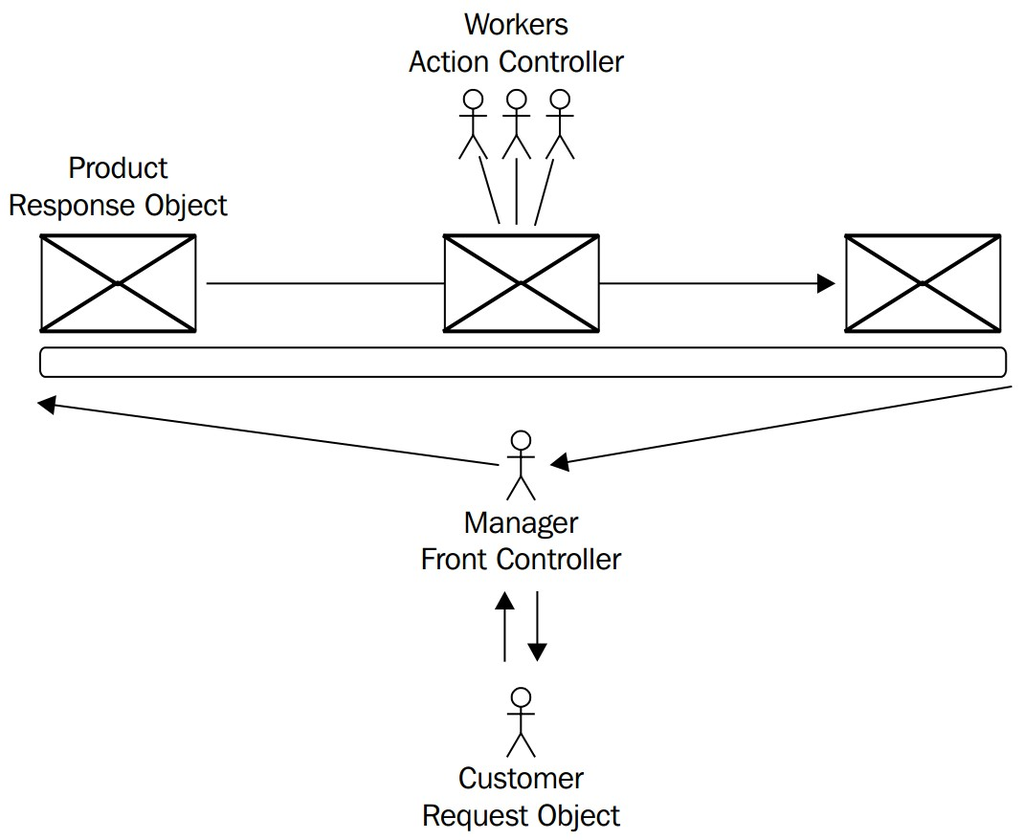

Rôle du front controller

# Architecture

[figure not shown]

Architecture de Laravel

# MVC

- Structure d’une appli web = [cycle Requête/Reponse](https://laravel.com/docs/master/lifecycle)
- Modèle : Eloquent ORM
- Vue : Blade Engine
- Contrôleur : hérite de BaseController

# Pratique

- Conventions de codage : Laravel respecte [PSR-2](https://laravel.com/docs/5.1/contributions#coding-style)
  - Vous aussi avec [StyleCI](https://styleci.io/)
- Editeurs et IDE : PhpStorm, [thimble](https://thimble.mozilla.org/fr/), brackets, Sublime Text, Atom, VS Code…
- Tests : unitaires, Jmeter, Selenium, …
- Outils : devtools Chrome ou FF, [Emmet](http://emmet.io/), git
- Doc
  - [Documentation officielle](https://laravel.com/docs/master) de Laravel
  - [Cheat Sheet](https://summerblue.github.io/laravel5-cheatsheet/#)
- Tutoriels
  - [Best Momo](http://laravel.sillo.org/laravel-5/), [Open Classroom](https://openclassrooms.com/courses/decouvrez-le-framework-php-laravel-1), [CodeSchool -> Pluralsight](https://www.codeschool.com/courses/try-laravel)

# Environnement de développement

- Local
  - Installation AMP, git + configuration : Long
  - Dépendant du poste de travail
  - Travail offline
  - Windows : [WSL](https://docs.microsoft.com/en-us/windows/wsl/install-win10) est votre ami !!!
- VM (Vagrant - [Homestead](https://laravel.com/docs/5.7/homestead)) ou conteneur
  - Mise en route plus rapide : pré-configuré
  - Environnement dédié au dev, identique pour chaque développeur
- Cloud (Cloud9, …)
  - Mise en route plus rapide : pré-configuré
  - Indépendant du poste de travail (navigateur)
  - Outils de synchro disponibles

# Environnement de développement

- Cloud: [Cloud9](https://github.com/dev-nowornet/Laravel-5.6-Complete-Install-Cloud9-C9)
- Local ou VM
  - Installer : serveur http, SGBD, git, php7, composer
  - Installer Laravel :

```bash
$composer global require "laravel/installer"
```

# Démarrer un projet

- Créer un nouveau projet

```bash
$ composer create-project laravel/laravel raidit
# ou si ~/.composer/vendor/bin est dans le PATH :
$ laravel new raidit
$ cd raidit
```

- Racine du site dans `/public` (lien symbolique ou virtual host)

# Le dépôt

- Initialiser le dépôt

```bash
$cd raidit
$git init
$git add .
$git commit -m "Install laravel"
$git remote add origin git@github.com:bastian/raidit.git
$git push --set-upstream origin master
```

- Penser à ajouter sa clé publique à Github

# [Apache](https://help.ubuntu.com/lts/serverguide/httpd.html)

- Virtual hosts
  - `http-vhosts.conf` (activer dans `httpd.conf`)
  - Un par site
  - Pointer dans `/public`
- `AllowOverride` : active `.htaccess`
- `.htaccess` : redirection des requêtes
- Alternative : Remplacer le dossier racine http par un lien symbolique vers le dossier `/public`

# Artisan

- Laravel’s CLI
- Construit avec Symfony Console
- Aide aux tâches courantes, ex:

```bash
$php artisan route:list
$php artisan migrate
$php artisan make:controller

$php artisan list
```

- [Extensible](https://laravel.com/docs/master/artisan)

# Premiers pas

- [Routes](https://laravel.com/docs/master/routing)
  - Ajouter une route `/test`
  - Ajouter un paramètre qui sera affiché : `/test/param`
  - Utiliser une vue pour cette route
  - Lister les routes avec la commande artisan
- [Contrôleurs](https://laravel.com/docs/master/controllers)
  - Ajouter un contrôleur : `Test`
  - Lui ajouter une action : `index`
  - Ajouter la route correspondante : `/test/index`
- [Vues](https://laravel.com/docs/master/views)
  - Ajouter une vue Blade (`.blade.php`)
  - Afficher cette vue dans l’action `index`

# Ressources

- [Laracast](https://laracasts.com/series/laravel-5-fundamentals)
- [Laravel Tips](https://laraveltips.wordpress.com/)
- [Learning Laravel](http://learninglaravel.net/tags/tutorials)
- [RESTful API with Laravel 5](http://www.tutorials.kode-blog.com/laravel-5-rest-api)
- [Les vôtres](https://github.com/HE-Arc/slides-devweb/wiki/Ressources)